# Linear Regression Models: Simple Linear Regression

## Predictive Modeling

Broadly, can organize goals as

- Unsupervised learning - goal is to learn about patterns and relationships in the data
  - No output to shoot for
- Supervised learning - a variable or variables in the data set represent an 'output' of interest
  - May wish to make **inference** on the model
  - Often just want to predict response(s)

## Unsupervised Learning

Commonly used unsupervised methods are

- Cluster analysis
- Market basket analysis
- Multiple dimensional scaling (MDS)
- Principal Components Analysis (PCA)
- Factor analysis

An inherently more difficult problem than supervised learning!

## Supervised Learning

Commonly used supervised methods are

- Regression models
  - Least squares
  - Penalized regression
  - Locally weighted/splines
  - Generalized linear models
- Tree based methods
  - Regression/classification trees
  - Random forests, boosting, bagging
- k Nearest Neighbors

… and many more, tons of methods!

## Predictive Modeling

Where to start?

- Not going to focus on inference (applied statistics sequence covers that well!)
- Start with basic linear regression models
- Expand to different *types* of responses in the **exponential family**
- Explore tree methods
- Look at ensemble type methods to improve prediction

Lastly, we'll look at some unsupervised methods like clustering and PCA

## Linear Regression vs Correlation

- Scatter Plot gives useful visualization
  - Always plot data!
- Investigated linear relationship between two with correlation
- Regression models allow easy prediction of response (and inference if desired)
- Use `lm()` function along with helpers like `predict()`

## Linear Regression Ideas

Recall the basic SLR model:

\[Y_i = \beta_0 + \beta_1x_i + E_i\] Here - \(Y_i\) is our response for the \(i^{th}\) observation  
- \(x_i\) is the value of our explanatory variable for the \(i^{th}\) observation  
- \(\beta_0\) is the y intercept  
- \(\beta_1\) is the slope

Model *fit* by minimizing the sum of squared residuals  
\[min_{\beta_0,\beta_1}\sum_{i=1}^{n}\left(y_i-\beta_0-\beta_1x_i\right)^2\]

## Linear Regression ideas

- Minimizing sum of squared errors is equivalent to assuming normality on errors and using maximum likelihood to estimate the \(beta\)'s

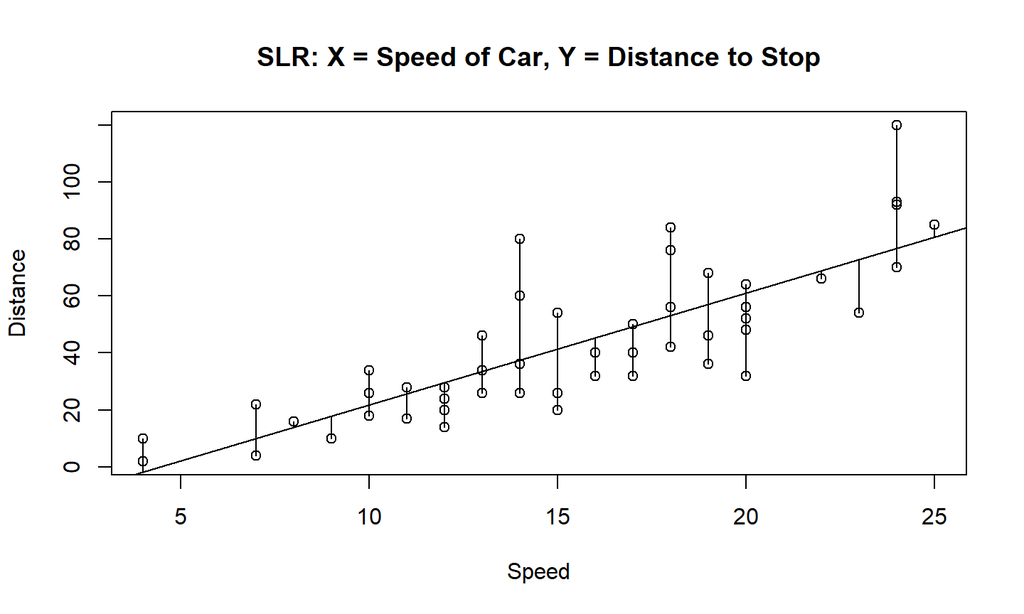

## Fitting the Model

- Basic *linear model* fits done with `lm()`

```r
lm(dist ~ speed, data = cars)
```

```
##
## Call:
## lm(formula = dist ~ speed, data = cars)
##
## Coefficients:
## (Intercept)        speed
##     -17.579        3.932
```

## Basic Analysis (Linear Regression)

- Save as object, check attributes

```r
fit <- lm(dist ~ speed, data = cars)
attributes(fit)
```

```
## $names
##  [1] "coefficients"  "residuals"     "effects"       "rank"
##  [5] "fitted.values" "assign"        "qr"            "df.residual"
##  [9] "xlevels"       "call"          "terms"         "model"
##
## $class
## [1] "lm"
```

- Three main ways to get at *many* of these attributes

```r
fit[[1]]
```

```
## (Intercept)       speed
##  -17.579095    3.932409
```

```r
coefficients(fit) #helper function
```

```
## (Intercept)       speed
##  -17.579095    3.932409
```

```r
fit$coefficients
```

```
## (Intercept)       speed
##  -17.579095    3.932409
```

- Three main ways to get at *many* of these attributes

```r
fit[[2]]
residuals(fit) #helper function
```

[output not shown]

```r
fit$residuals
```

```
##          1          2          3          4          5          6
##   3.849460  11.849460  -5.947766  12.052234   2.119825  -7.812584
##          7          8          9         10         11         12
##  -3.744993   4.255007  12.255007  -8.677401   2.322599 -15.609810
##         13         14         15         16         17         18
##  -9.609810  -5.609810  -1.609810  -7.542219   0.457781   0.457781
##         19         20         21         22         23         24
##  12.457781 -11.474628  -1.474628  22.525372  42.525372 -21.407036
##         25         26         27         28         29         30
## -15.407036  12.592964 -13.339445  -5.339445 -17.271854  -9.271854
##         31         32         33         34         35         36
##   0.728146 -11.204263   2.795737  22.795737  30.795737 -21.136672
##         37         38         39         40         41         42
## -11.136672  10.863328 -29.069080 -13.069080  -9.069080  -5.069080
##         43         44         45         46         47         48
##   2.930920  -2.933898 -18.866307  -6.798715  15.201285  16.201285
##         49         50
##  43.201285   4.268876
```

## Basic Analysis (Linear Regression)

- Statistical analysis found using `anova()` or `summary()`

```r
#ANOVA table (F tests)
anova(fit)
```

```
## Analysis of Variance Table
##
## Response: dist
##           Df Sum Sq Mean Sq F value   Pr(>F)
## speed      1  21186 21185.5  89.567 1.49e-12 ***
## Residuals 48  11354   236.5
## ---
## Signif. codes:  0 '***' 0.001 '**' 0.01 '*' 0.05 '.' 0.1 ' ' 1
```

## Basic Analysis (Linear Regression)

- Statistical analysis found using `anova()` or `summary()`

```r
#coefficient type III tests
summary(fit)
```

```
##
## Call:
## lm(formula = dist ~ speed, data = cars)
##
## Residuals:
##     Min      1Q  Median      3Q     Max
## -29.069  -9.525  -2.272   9.215  43.201
##
## Coefficients:
##             Estimate Std. Error t value Pr(>|t|)
## (Intercept) -17.5791     6.7584  -2.601   0.0123 *
## speed         3.9324     0.4155   9.464 1.49e-12 ***
## ---
## Signif. codes:  0 '***' 0.001 '**' 0.01 '*' 0.05 '.' 0.1 ' ' 1
##
## Residual standard error: 15.38 on 48 degrees of freedom
## Multiple R-squared:  0.6511, Adjusted R-squared:  0.6438
## F-statistic: 89.57 on 1 and 48 DF,  p-value: 1.49e-12
```

## Basic Analysis (Linear Regression)

- Diagnostic plots easily found using `plot()`
- Run this code in console

```r
plot(fit)
```

## Basic Analysis (Linear Regression)

- Add fit to our scatter plot
- Compare to a smoothed fit (here a locally weighted estimate)

```r
ggplot(cars, aes(x = speed, y = dist)) +
  geom_point() +
  geom_smooth(method = "lm") +
  geom_smooth(col = "red")
```

## Basic Analysis (Linear Regression)

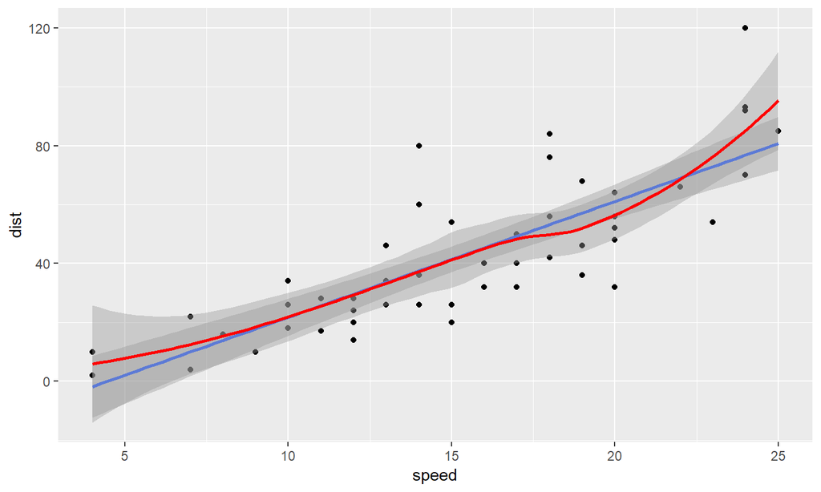

## Basic Analysis (Linear Regression)

- Now can predict y for a given x
- Check `help(predict)`, particularly `predict.lm()`

```r
predict(fit, newdata = data.frame(speed = c(42, 5)))
```

```
##          1          2
## 147.582073   2.082949
```

## Basic Analysis (Linear Regression)

- Get SE for prediction

```r
predict(fit, newdata = data.frame(speed = c(42, 5)), se.fit = TRUE)
```

```
## $fit
##          1          2
## 147.582073   2.082949
##
## $se.fit
##         1         2
## 11.264612  4.837825
##
## $df
## [1] 48
##
## $residual.scale
## [1] 15.37959
```

## Basic Analysis

- Get confidence interval for mean response

```r
predict(fit, newdata = data.frame(speed = c(42, 5)),
        se.fit = TRUE, interval = "confidence")
```

```
## $fit
##          fit       lwr       upr
## 1 147.582073 124.93305 170.23109
## 2   2.082949  -7.64415  11.81005
##
## $se.fit
##         1         2
## 11.264612  4.837825
##
## $df
## [1] 48
##
## $residual.scale
## [1] 15.37959
```

## Basic Analysis

- Get prediction interval for new response

```r
predict(fit, newdata = data.frame(speed = c(42, 5)),
        se.fit = TRUE, interval = "prediction")
```

```
## $fit
##          fit       lwr       upr
## 1 147.582073 109.25201 185.91213
## 2   2.082949 -30.33359  34.49948
##
## $se.fit
##         1         2
## 11.264612  4.837825
##
## $df
## [1] 48
##
## $residual.scale
## [1] 15.37959
```

- Confidence interval is automatically added to ggplot scatter plots with a `geom_smooth()` (called `se` unfortunately…)

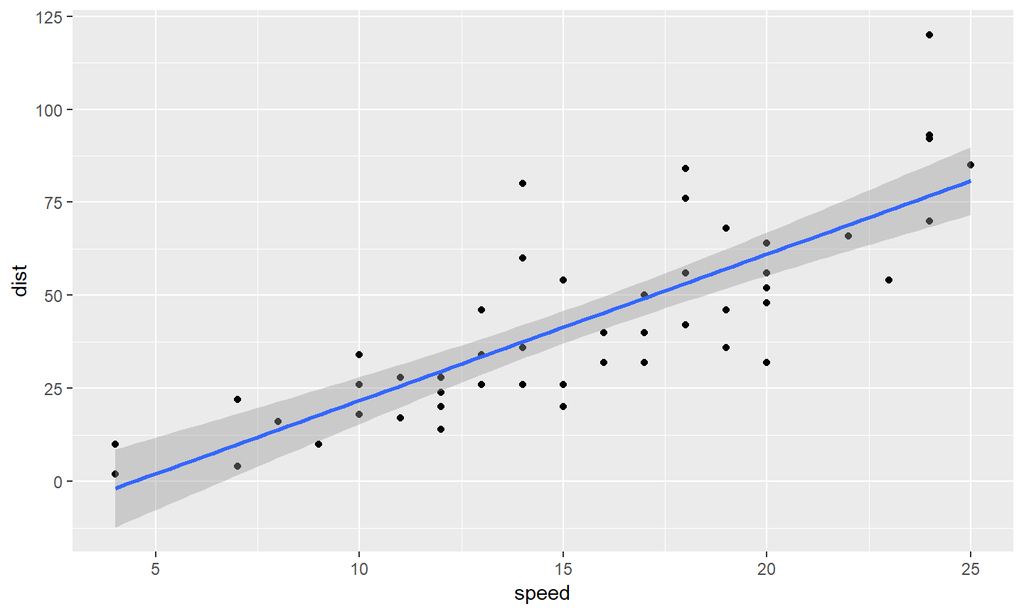

```r
ggplot(cars, aes(x = speed, y = dist)) + geom_point() +
  geom_smooth(method = "lm", se = TRUE) #TRUE by default, 95% CI
```

## Basic Analysis

- Add PI easily with packages (install `ciTools` package)

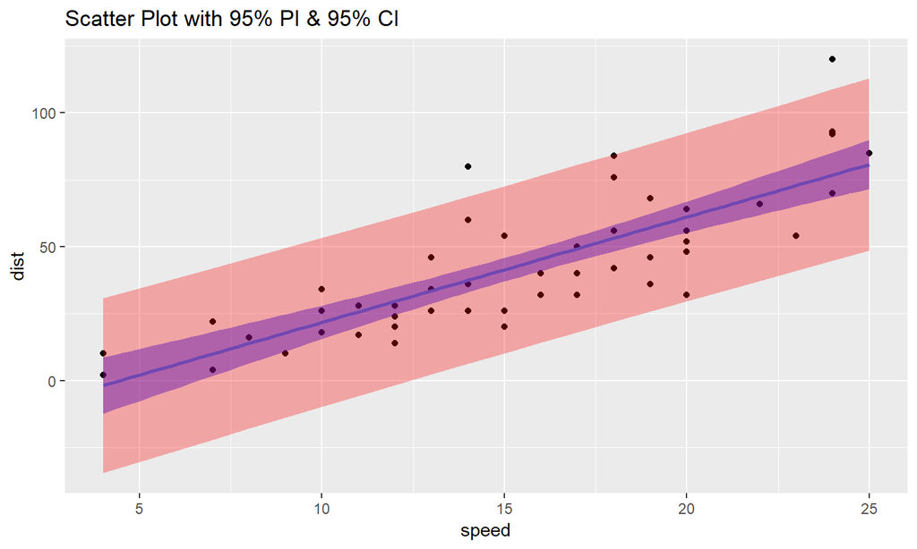

```r
cars <- cars %>% ciTools::add_pi(fit, names = c("lower", "upper"))

ggplot(cars, aes(x = speed, y = dist)) +
  geom_point() +
    geom_smooth(method = "lm", fill = "Blue") +
    geom_ribbon(aes(ymin = lower, ymax = upper), alpha = 0.3, fill = "Red") +
    ggtitle("Scatter Plot with 95% PI & 95% CI")
```